# A4: Incarceration

### Introduction

Currently the United States holds the unfortunate distinction of having the highest incarceration rate in the world, with a significant portion of its population behind bars. Particularly concerning is the over representation of people of color, especially Black individuals, in the criminal justice system. This disparity in incarceration rates is a troubling reflection of both historical and current-day racism that continues to shape the American society. In this introduction, we highlight the urgent need to address these issues and take a deeper dive into prison population here in Washington State, and its counties. This data set will give a more presentable scale of the people incarcerated here in the Washington; diving deep into the make up of the prison population here in Washington.

### Summary Information

```
## # A tibble: 39 × 2
##    county_name         average_total_prison_pop
##    <chr>                                  <dbl>
##  1 Whitman County                          73.7
##  2 San Juan County                         91.8
##  3 Island County                          149.
##  4 Jefferson County                       198.
##  5 Pend Oreille County                    248.
##  6 Stevens County                         250.
##  7 Lincoln County                         254.
##  8 Snohomish County                       254.
##  9 Kittitas County                        258.
## 10 Douglas County                         268.
## # ℹ 29 more rows
```

```
## # A tibble: 39 × 2
##    county_name     average_black_prison_pop_county
##    <chr>                                     <dbl>
##  1 Adams County                                 0
##  2 Asotin County                              NaN
##  3 Benton County                             2021.
##  4 Chelan County                             1419.
##  5 Clallam County                             929.
##  6 Clark County                              1675.
##  7 Columbia County                              0
##  8 Cowlitz County                            4150.
##  9 Douglas County                               0
## 10 Ferry County                                 0
## # ℹ 29 more rows
```

```
## # A tibble: 39 × 2
##    county_name     average_white_prison_pop
##    <chr>                              <dbl>
##  1 Adams County                        282.
##  2 Asotin County                       480.
##  3 Benton County                       282.
##  4 Chelan County                       434.
##  5 Clallam County                      314.
##  6 Clark County                        345.
##  7 Columbia County                     356.
##  8 Cowlitz County                      712.
##  9 Douglas County                      266.
## 10 Ferry County                        339.
## # ℹ 29 more rows
```

```
## # A tibble: 39 × 2
##    county_name     average_latinx_prison_pop
##    <chr>                               <dbl>
##  1 Adams County                         287.
##  2 Asotin County                       1102.
##  3 Benton County                        466.
##  4 Chelan County                        807.
##  5 Clallam County                       596.
##  6 Clark County                         503.
##  7 Columbia County                        0
##  8 Cowlitz County                      2699.
##  9 Douglas County                       392.
## 10 Ferry County                           0
## # ℹ 29 more rows
```

```
## # A tibble: 39 × 2
##    county_name     average_native_prison_pop
##    <chr>                               <dbl>
##  1 Adams County                           0
##  2 Asotin County                       2360.
##  3 Benton County                        654.
##  4 Chelan County                       1993.
##  5 Clallam County                       482.
##  6 Clark County                        1145.
##  7 Columbia County                        0
##  8 Cowlitz County                      1541.
##  9 Douglas County                      1633.
## 10 Ferry County                           0
## # ℹ 29 more rows
```

```
## # A tibble: 39 × 2
##    county_name     average_aapi_prison_pop
##    <chr>                             <dbl>
##  1 Adams County                        0
##  2 Asotin County                     NaN
##  3 Benton County                     193.
##  4 Chelan County                       0
##  5 Clallam County                      0
##  6 Clark County                       91.3
##  7 Columbia County                     0
##  8 Cowlitz County                      0
##  9 Douglas County                      0
## 10 Ferry County                        0
## # ℹ 29 more rows
```

### The Dataset

Who collected the data?

Vera Institute of Justice

How was the data collected or generated?

It was complied together by the Vera Institute, collecting data that was already collected from different sources. The U.S. Department of Justice Bureau of Justice Statistics (BJS) gathers data from all jails and prisons every 5-8 years.

Why was the data collected?

The data was collected to showcase and expose patterns or trends of inequality regarding incarceration here in the US and all across the states. It is meant to provide an statically analysis on inequality among certain ethnicity groups and determine the underlying cause.

How many observations (rows) are in your data?

There are 1131 observation or rows in this data.

How many features (columns) are in the data?

There are 23 features or columns in this data.

What, if any, ethical questions or questions of power do you need to consider when working with this data?

When working with this data, it’s important to consider who or what has a significant influence on policies and laws. It’s also crucial to think about the narrative that can be derived from the data and how we are using it. Beyond the numbers and statistics, there are questions about privacy, fairness, and representation of people’s voices. It’s essential to examine the data’s origins and investigate any potential biases that may have been introduced during collection. At the same time, we must recognize the power and influence that comes with working with this data, and acknowledge that those who generate, collect, and interpret it hold significant sway. Engaging affected communities is a critical ethical aspect, ensuring that incarcerated individuals’ and advocacy groups’ voices are included and respected throughout the analysis process.

What are possible limitations or problems with this data?

The dataset we currently have only gathered data from Washington State and its counties, which limits its scope to that specific area. While it’s useful to know which county has the highest average of certain ethnic groups, it only represents a fraction of the racial inequality present in the country. Different states may face varying degrees of racial inequality, and relying on just one state’s data restricts the amount of information we can obtain. A more comprehensive dataset that covers all US states would give us a better idea of how incarceration disproportionately affects all ethnic groups nationwide. Such a dataset would clearly highlight the impact in each region of the country, and help identify areas where we can make improvements. The current dataset from Washington State and its counties has limitations that may not accurately reflect the true scale of the problem. A dataset that covers all US states and their incarceration rates would provide a more accurate depiction of the issue, and potentially present solutions to address the underlying problems. Nevertheless, the current dataset still provides a significant amount of information and sheds light on the severity of the issue in Washington State and its counties.

### Trend Over Time

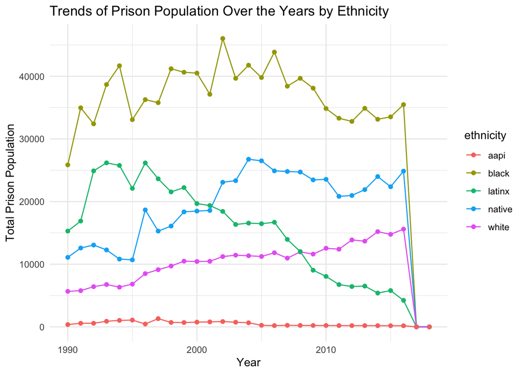

I created a graph that displays the trend of each ethnic group’s representation in the overall prison population. The data was collected from different counties in Washington State and tallied to create a sum for each ethnic group in a given year. This process was repeated for every year in the dataset, covering all ethnicities listed in the CSV file. By plotting one point for each year and connecting the dots, the graph provides a clear visualization of the changes in the prison population and emerging trends. The graph indicates that only the Latin and AAPI ethnic groups have shown a decrease in prison population over the years, while all other ethnic groups have increased. This trend can help solve various problems by providing insight into ongoing changes in the prison population over time.

### Variable Comparison Chart

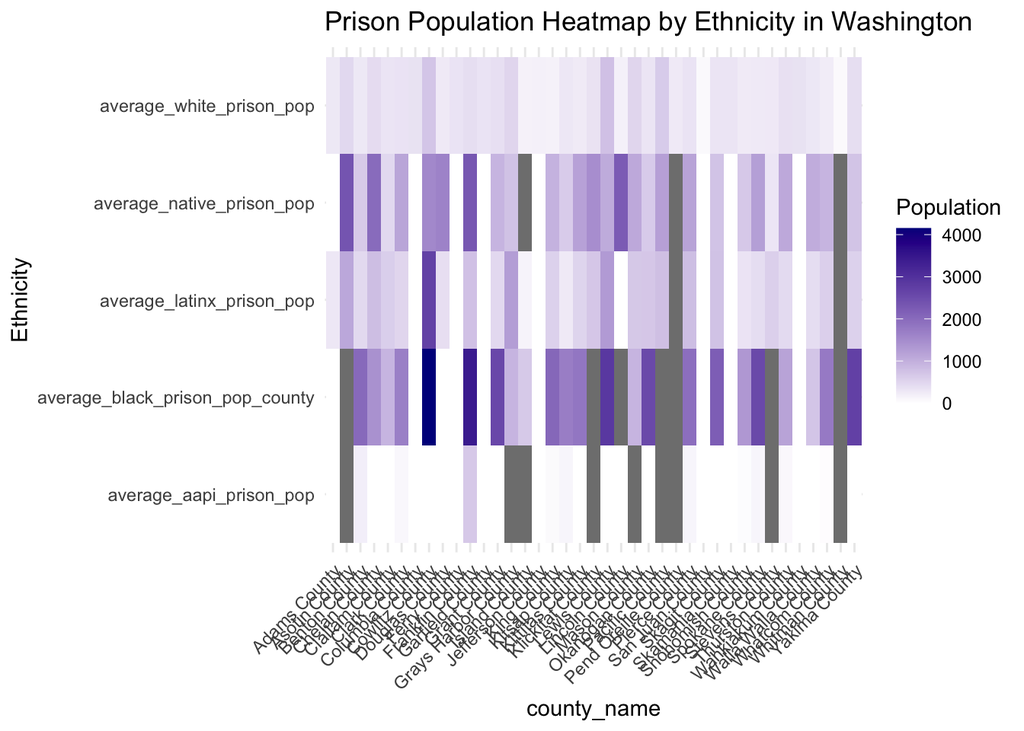

I created a heat map to display the average density of each ethnicity across all counties in Washington State. This map helps to visualize the differences in the density of each ethnicity in the state’s prison population and shows which counties have the highest or lowest density for a particular ethnicity. The black and native prison populations are among the densest in the majority of counties, which is consistent with the data displayed in the trend graph. Although the results are consistent, the heat map provides a different visual representation of the data.

### Map

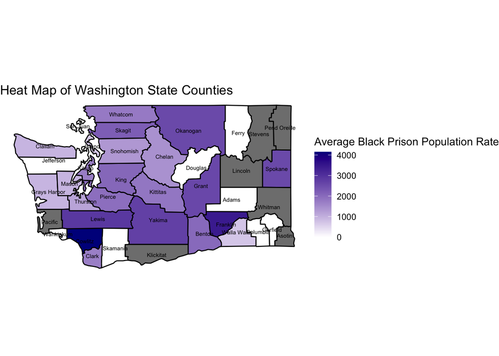